# Open-source et logiciel libre

2 Février 2019

## Introduction

## Qui parmi vous utilise des logiciels open-source ou libres ?

- Firefox
- R
- OpenOffice / LibreOffice
- VLC
- GIMP
- Linux (GNU/Linux)
- Git/Github

## Problématique

### Le logiciel libre et/ou open-source est-il encore d'actualité aujourd'hui ?

## Définitions

## Logiciel libre

- 1983: lancement officiel de GNU
- Richard Stallman (1953- )

### Les quatre libertés (Stallman 2002: 43)

- 0: liberté d'utiliser le logiciel à n'importe quelle fin
- 1: liberté d'étudier le logiciel et de l'adapter à ses besoins
- 2: liberté de redistribuer le logiciel
- 3: liberté d'améliorer le logiciel et de partager les améliorations

## Open-source

- Terme développé Bruce Perence et Eric Raymond en 1998 (Deek et McHugh 2008:297)
- Une forme de démocratisation liée au développement d'internet
- Définition de l'OSI basée sur 10 critères (Deek et McHugh 2008:246)
- Critique de Richard Stallman (Gay 2002: 57-62)

## Copyleft et licences

- Réaction au copyright (Stallman 2002: 91)
- Toutes les versions améliorées ou modifiées du programme doivent être libres également (ibid.)
- Licence GNU GPL
- Exemple de X Window System (Stallman 2002: 22)

[figure not shown]

## Un âge d'or… ?

## Les débuts à MIT

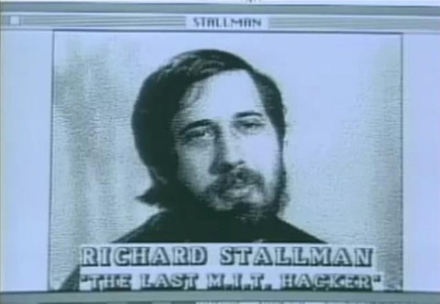

## Les débuts à MIT

- MIT AI Lab - PDP-11 (Stallman 2002: 17)
- VAX/68020 : départ de Stallman
- 1983: début du projet GNU (Gnu's Not Unix) et protocole TCP-IP devient une norme
- 1985: Free Software Foundation

## Internet comme catalyseur: GNU, GNU/Linux et les browsers

[figure not shown]

## Internet comme catalyseur: GNU, GNU/Linux et les browsers

- Manque d'ergonomie au début
- L'email et le protocole de transfert de ficher (FTP) facilite les échanges (Deek et McHugh 2008: 119)
- 1992: GNU/Linux, premier système d'exploitation entièrement libre
- Dans la foulée, les premiers browsers: Mosaic, Netscape, Firefox (Deek et McHugh 2008: 37-48)

## …Suivi d'un déclin ?

## Un déclin apparent

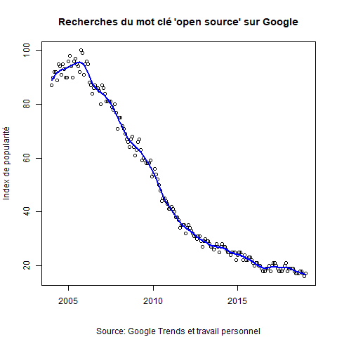

## Mais trompeur

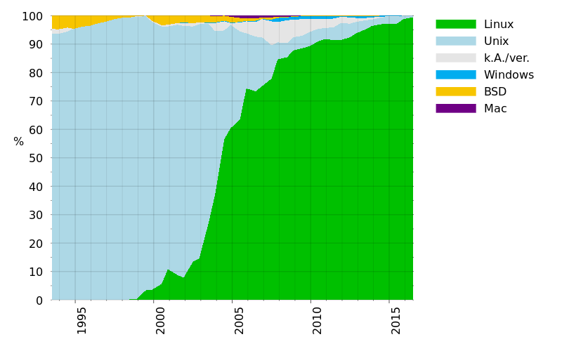

## En réalité

- Banalisation dans les usages personnels et commerciaux
- Licences sur Github mais aussi dans les entreprises (Nevo et Chengalur-Smith 2017)

## Bibliographie

## Ouvrages et lien vers mon code

- Deek, F. P. and McHugh, J. A. (2008). *Open Source. Technology and Policy*. Cambridge: Cambridge University Press.
- Gay, J., ed. (2002). *Free Software Free Society. Selected essays of Richard M. Stallman*. Boston: GNU Press.
- Nevo, S. and Chengalur-Smith, I. (2017). ‘Examining organizations’ continued use of open source technologies’. *Information Technology and People*, vol. 30, no. 1, pp 24-46.
- Söderberg, J. (2008). *Hacking Capitalism. The Free and Open Source Software Movement*. New York: Routledge.
- https://github.com/julesbeley/Presentation

## Illustrations

https://upload.wikimedia.org/wikipedia/commons/thumb/9/93/GPLv3_Logo.svg/1200px-GPLv3_Logo.svg.png

https://pbs.twimg.com/media/CNTUaPxXAAAO69Q.png

https://upload.wikimedia.org/wikipedia/commons/3/30/Operating_systems_used_on_top_500_supercomputers_de.svg

https://steemitimages.com/p/368La1qZAv72bxJGnETG1PXbY7SfpAgErEjmGQaJ29KQT624j5XKwc1JS2gFZPuN19cpuyfCGwN43pTtJDtvpEM4?format=match&mode=fit&width=640

## Article récent du Monde sur VLC

[figure not shown]

[Lien](https://www.lemonde.fr/pixels/article/2019/01/28/l-irresistible-ascension-du-lecteur-video-vlc-une-revolution-francaise_5415762_4408996.html)